# Key 11 ANCOVA

**Instructions for writing KEY and HW**

1. update libraries and data
   1. In setup block (hidden) and in **SETUP** sections below
2. Add graded comment to code block and as a 2nd-level header above problem
3. Once Key is complete
   1. Delete this instruction callout
   2. Render
4. After key is complete
   1. “save as” appropriate HW in `assignment/` folder
   2. Change `echo:` and `eval:` to `false` in YAML
   3. Delete GRADED headers
   4. Render assignment
      1. Ensure that code and output are not visible

# Learning Objectives

- Complete a homework using Quarto to render an html document
- Conduct an ANCOVA analysis and interpret the results

# Setup

## Quarto

- This will be the first assignment which asks you to summarize your analysis results using Quarto
- Start by opening a new Quarto document
- The title will be “Week 11 ANCOVA”
- Be sure to put your name in as the Author
- After opening a new Quarto document, make sure to include the following in your YAML header:

```
toc: true
toc-depth: 2
embed-resources: true
```

## Download the limpet data

- Download the “limpet.csv” from D2L
- Place it in your `data/` folder

## **Setup** code chunk

- You will need to load the `tidyverse` and the `limpet.csv` data
- Insert an R code chunk at the top of your Quarto document
- Include the following in the code chunk to load the library and the data

```
#| label: setup
#| include: true
#| eval: true
#| warning: false
library(tidyverse)
limp <- read.csv(here::here("data/limpet.csv")) |>
  as_tibble()
```

# Data

- The `limpet.csv` data is originally from Quinn and Keough’s 2002 book Experimental Design and Data Analysis for Biologists.
- The data relate egg production by limpets to four density conditions in two seasons.
- `EGGS` is the response variable (y) and measures the amount of egg production
- `SEASON` is a **categorical** predictor variable (x).
- `DENSITY` is a **continuous** predictor variable (x)
- Because we are examining egg production along a continuous density gradient, this is essentially a study of density-dependent reproduction.
- The experimental manipulation of density was implemented in spring and in summer.
- Thus, a motivation for collecting these data could be ‘does the density dependence of egg production differ between spring and summer’?
- Density dependence is the idea that as the number of individuals sharing a food resource increases (e.g. their density goes up), they get a smaller and smaller portion of that food, leading to reduced reproduction success.

# Problems

- Your final assignment will be a rendered html document
- As such, you will be writing code and answering questions a little bit differently
- For each question, put the question number in your document as a second-level heading, for example:

```
## 1.1
code chunk or answer

## 1.2
code chunk or answer

## 1.3
code chunk or answer

etc.
```

- In general, when a question asks you to do anything with the data (modify, calculate, plot, fit a model), you will insert a new code chunk to perform that calculation
- When a question asks you to interpret your results or answer something in plain words, you will just write out your answer below that problem heading.
- For example:

```
## 1.4
It appears that `EGGS` is related to `DENSITY` because...
```

## Problem 1: `limpet`

1.1 Print the `names()` and `head()` of your data object here.

```r
#
names(limp)
```

```
[1] "DENSITY" "SEASON"  "EGGS"
```

```r
head(limp)
```

```
# A tibble: 6 × 3
  DENSITY SEASON  EGGS
    <int> <chr>  <dbl>
1       8 spring  2.88
2       8 spring  2.62
3       8 spring  1.75
4       8 summer  2.12
5       8 summer  1.5
6       8 summer  1.88
```

1.2 Add a code chunk which reports the class of each variable in the limpet data. Recall that `SEASON` and `DENSITY` are our predictor variables and `EGGS` is the response variable.

```r
class(limp$DENSITY) # numeric or continuous also accepted
```

```
[1] "integer"
```

```r
class(limp$SEASON) # Character
```

```
[1] "character"
```

```r
class(limp$EGGS) # double <dbl> or continuous also accepted
```

```
[1] "numeric"
```

1.3 Produce a scatter plot of the data with `EGGS` as the response variable and `DENSITY` as the predictor variable.

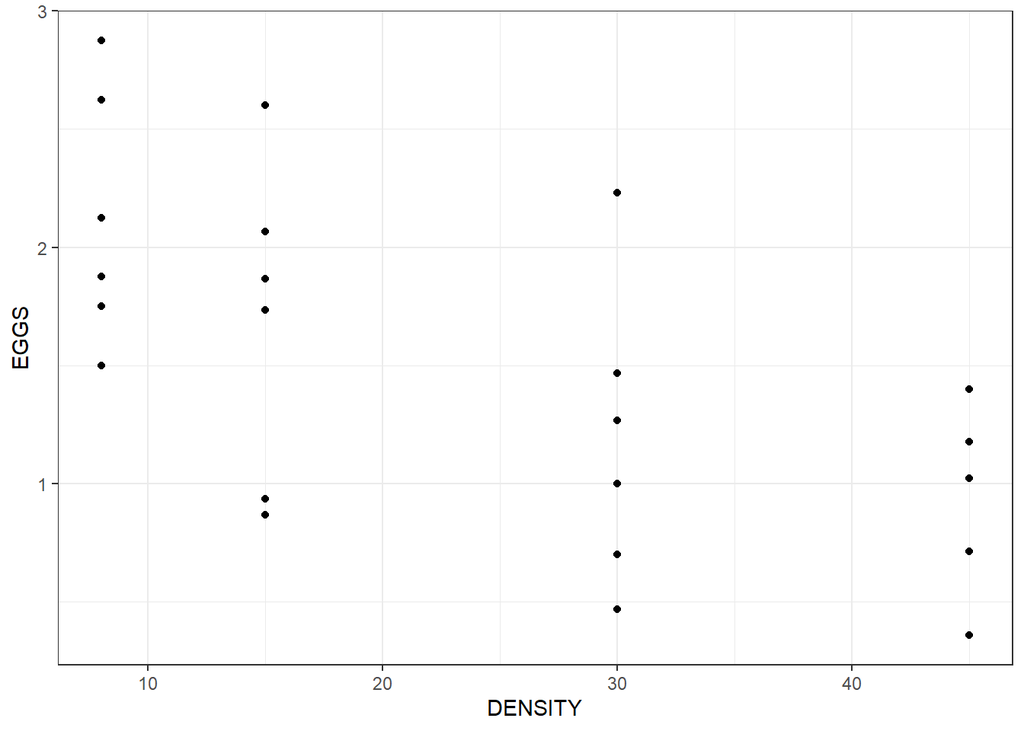

```r
ggplot(limp,
       aes(y = EGGS,
           x = DENSITY)) +
  geom_point() +
  theme_bw()
```

1.4 Does there appear to be a linear relationship between the number of eggs and increasing population density? Why or why not?

```r
# Yes, it appears that the number of eggs declines with increasing density. There does not appear to be any curvature in the response, or any changes in slope across the x-variable.
```